# Índice de Desarrollo Humano

Maria Lucia Guastoni

26/2/2021

El Índice de Desarrollo Humano (IDH) es un índice compuesto que calcula la Organización de Naciones Unidas (ONU), dentro del Programa de las Naciones Unidas sobre el Desarrollo, como medida del nivel de desarrollo de los países más adecuada que el simple PIB per capita, al tener en cuenta más dimensiones relacionadas con el desarrollo que el simple nivel de renta nivel de renta indi- vidual. Además de esta última variable, tiene en cuenta la esperanza de vida al nacer, los años esperados de escolarización y la media de años de escolarización. La medida viene calculándose desde 1990, ha ido sufriendo algunos cambios metodológicos a lo largo de los últimos 30 años, y ha ido perfeccionándose y complementándose con nuevos indicadores parciales que recogen aspectos tales como la desigualdad o las diferencias de genero, por citar algunos aspectos.

Se comenzará leyendo los datos:

```r
df <- read.csv2("../componentes principales/data_HDI_2019.csv")
dim(df)
```

```
[1] 189  23
```

Luego, se calcula la matriz de correlación del dataset:

```r
round(cor(df[,-1], use = "pairwise.complete.obs"),2)
```

```
              HDI   LEB EYEDU MYEDU GNIpc  IHDI   CHI IN_LE IN_EDU IN_INC
HDI          1.00  0.91  0.90  0.92  0.79  0.98 -0.90 -0.92  -0.83  -0.38
LEB          0.91  1.00  0.79  0.77  0.70  0.92 -0.86 -0.95  -0.73  -0.41
EYEDU        0.90  0.79  1.00  0.81  0.66  0.91 -0.81 -0.80  -0.73  -0.35
MYEDU        0.92  0.77  0.81  1.00  0.67  0.94 -0.90 -0.83  -0.92  -0.36
GNIpc        0.79  0.70  0.66  0.67  1.00  0.85 -0.72 -0.69  -0.58  -0.38
IHDI         0.98  0.92  0.91  0.94  0.85  1.00 -0.95 -0.94  -0.89  -0.51
CHI         -0.90 -0.86 -0.81 -0.90 -0.72 -0.95  1.00  0.91   0.90   0.65
IN_LE       -0.92 -0.95 -0.80 -0.83 -0.69 -0.94  0.91  1.00   0.81   0.42
IN_EDU      -0.83 -0.73 -0.73 -0.92 -0.58 -0.89  0.90  0.81   1.00   0.33
IN_INC      -0.38 -0.41 -0.35 -0.36 -0.38 -0.51  0.65  0.42   0.33   1.00
INC_40_POOR  0.38  0.43  0.33  0.36  0.40  0.49 -0.57 -0.43  -0.27  -0.84
INC_10_RICH -0.45 -0.48 -0.36 -0.42 -0.46 -0.53  0.59  0.47   0.32   0.80
INC_1_RICH  -0.32 -0.35 -0.31 -0.32 -0.22 -0.46  0.48  0.31   0.25   0.64
GINI        -0.42 -0.46 -0.35 -0.40 -0.43 -0.52  0.59  0.45   0.30   0.84
GII         -0.92 -0.86 -0.84 -0.85 -0.80 -0.94  0.89  0.89   0.80   0.48
MMR         -0.78 -0.83 -0.69 -0.70 -0.50 -0.78  0.77  0.86   0.72   0.30
ABR         -0.77 -0.78 -0.65 -0.69 -0.63 -0.81  0.76  0.81   0.63   0.42
SSP_F        0.28  0.28  0.33  0.24  0.22  0.31 -0.28 -0.25  -0.21  -0.09
P2EDU_F      0.85  0.70  0.73  0.95  0.60  0.89 -0.88 -0.80  -0.89  -0.38
P2EDU_M      0.82  0.67  0.72  0.93  0.58  0.86 -0.85 -0.76  -0.84  -0.41
LFP_F       -0.14 -0.19 -0.04 -0.09  0.03 -0.14  0.13  0.20   0.03   0.11
LFP_M       -0.21 -0.10 -0.22 -0.26 -0.10 -0.28  0.23  0.14   0.17   0.16
            INC_40_POOR INC_10_RICH INC_1_RICH  GINI   GII   MMR   ABR SSP_F
HDI                0.38       -0.45      -0.32 -0.42 -0.92 -0.78 -0.77  0.28
LEB                0.43       -0.48      -0.35 -0.46 -0.86 -0.83 -0.78  0.28
EYEDU              0.33       -0.36      -0.31 -0.35 -0.84 -0.69 -0.65  0.33
MYEDU              0.36       -0.42      -0.32 -0.40 -0.85 -0.70 -0.69  0.24
GNIpc              0.40       -0.46      -0.22 -0.43 -0.80 -0.50 -0.63  0.22
IHDI               0.49       -0.53      -0.46 -0.52 -0.94 -0.78 -0.81  0.31
CHI               -0.57        0.59       0.48  0.59  0.89  0.77  0.76 -0.28
IN_LE             -0.43        0.47       0.31  0.45  0.89  0.86  0.81 -0.25
IN_EDU            -0.27        0.32       0.25  0.30  0.80  0.72  0.63 -0.21
IN_INC            -0.84        0.80       0.64  0.84  0.48  0.30  0.42 -0.09
INC_40_POOR        1.00       -0.91      -0.63 -0.98 -0.47 -0.31 -0.50  0.08
INC_10_RICH       -0.91        1.00       0.67  0.97  0.54  0.31  0.55 -0.10
INC_1_RICH        -0.63        0.67       1.00  0.66  0.43  0.16  0.34 -0.29
GINI              -0.98        0.97       0.66  1.00  0.51  0.32  0.54 -0.09
GII               -0.47        0.54       0.43  0.51  1.00  0.73  0.81 -0.39
MMR               -0.31        0.31       0.16  0.32  0.73  1.00  0.69 -0.18
```

[output cut: 14 more lines]

```
IN_LE         -0.80   -0.76  0.20  0.14
IN_EDU        -0.89   -0.84  0.03  0.17
IN_INC        -0.38   -0.41  0.11  0.16
INC_40_POOR    0.40    0.42 -0.24 -0.24
INC_10_RICH   -0.45   -0.47  0.22  0.28
INC_1_RICH    -0.34   -0.36  0.06  0.46
GINI          -0.43   -0.45  0.23  0.26
GII           -0.81   -0.79 -0.04  0.27
MMR           -0.71   -0.67  0.27  0.08
ABR           -0.69   -0.68  0.28  0.23
SSP_F          0.15    0.14  0.22 -0.02
P2EDU_F        1.00    0.97 -0.07 -0.31
P2EDU_M        0.97    1.00 -0.06 -0.32
LFP_F         -0.07   -0.06  1.00  0.37
LFP_M         -0.31   -0.32  0.37  1.00
```

#### 1. Realiza un análisis de componentes principales de los datos anteriores

```r
set.seed(1)
colSums(is.na(df)) # valores nulos hay por columna
```

```
    COUNTRY         HDI         LEB       EYEDU       MYEDU       GNIpc
          0           0           0           0           0           0
       IHDI         CHI       IN_LE      IN_EDU      IN_INC INC_40_POOR
         37          37           6          18          33          37
INC_10_RICH  INC_1_RICH        GINI         GII         MMR         ABR
         37          71          37          27           7           6
      SSP_F     P2EDU_F     P2EDU_M       LFP_F       LFP_M
          2          22          22          11          11
```

```r
df <- na.omit(df) # se eliminan las observaciones con valores nulos
rownames(df) <- df$COUNTRY # se fija como índice el nombre de los países
df <- select(df, -"HDI") # se quita la variable dependiente del dataset
pca <- prcomp(df[-1], scale = TRUE)
summary(pca)
```

```
Importance of components:
                          PC1    PC2     PC3    PC4     PC5     PC6     PC7
Standard deviation     3.6651 1.6647 1.22520 0.9447 0.82303 0.60743 0.55997
Proportion of Variance 0.6397 0.1320 0.07148 0.0425 0.03226 0.01757 0.01493
Cumulative Proportion  0.6397 0.7716 0.84312 0.8856 0.91787 0.93544 0.95037
                           PC8     PC9    PC10    PC11    PC12    PC13    PC14
Standard deviation     0.49754 0.43593 0.37924 0.35598 0.34474 0.25837 0.24866
Proportion of Variance 0.01179 0.00905 0.00685 0.00603 0.00566 0.00318 0.00294
Cumulative Proportion  0.96216 0.97121 0.97806 0.98409 0.98975 0.99293 0.99587
                         PC15    PC16    PC17    PC18    PC19    PC20     PC21
Standard deviation     0.1712 0.15741 0.13510 0.10659 0.05273 0.01291 0.002024
Proportion of Variance 0.0014 0.00118 0.00087 0.00054 0.00013 0.00001 0.000000
Cumulative Proportion  0.9973 0.99845 0.99932 0.99986 0.99999 1.00000 1.000000
```

Puede verse que el primer Componente Principal explica el 64% de la variación total de los datos, mientras que la segunda solo el 13,2%. Entre las primeras tres CPs se explica casi el 85%.

#### 2. Interpreta la primera y la segunda componente principal a partir de los vectores de cargas.

##### Componente 1

```r
sort(pca$rotation[,1])
```

```
       IHDI         LEB       MYEDU     P2EDU_F     P2EDU_M       EYEDU
-0.26782929 -0.25670092 -0.25305946 -0.24896708 -0.24396553 -0.23743001
      GNIpc INC_40_POOR       SSP_F       LFP_F       LFP_M  INC_1_RICH
-0.23712103 -0.18081850 -0.10496049  0.05556318  0.13281258  0.15801016
     IN_INC        GINI INC_10_RICH         MMR      IN_EDU         ABR
 0.17476028  0.18787785  0.18962196  0.22472628  0.23704360  0.24670695
        GII       IN_LE         CHI
 0.25993285  0.26028232  0.26487839
```

Se observa que las variables originales más correlacionadas negativamente con el CP1 son `IHDI` (Inequality-adjusted HDI) y `LEB` (Life expectancy at birth). Es decir, cuando el Indice de Desarrollo Humano ajustado (que toma en cuenta el nivel de desigualdad en una sociedad) y la expectativa de vida al nacer aumentan, el valor del CP1 disminuye.

Por otro lado, las tres variables más correlacionadas positivamente con el CP1 son `CHI` (Coeficient of human inequality), `IN_LE` (Inequality in life expectancy) y `GII` (Gender Inequality Index). Cuando estas variables aumentan, también lo hace CP1.

Pareciera entonces que el CP1 tiene una relación negativa con el IDH.

##### Componente 2

```r
sort(pca$rotation[,2])
```

```
INC_40_POOR      IN_EDU         MMR         GII       IN_LE         CHI
-0.41368354 -0.21350736 -0.15930904 -0.09666880 -0.09580271 -0.02403727
        ABR         LEB       LFP_M       GNIpc        IHDI       SSP_F
-0.02384434  0.05066230  0.06857064  0.07960396  0.08394436  0.12184578
    P2EDU_M     P2EDU_F       MYEDU       EYEDU       LFP_F  INC_1_RICH
 0.13131571  0.14097002  0.15973748  0.17129851  0.19422163  0.32228852
     IN_INC INC_10_RICH        GINI
 0.37501850  0.39580343  0.41456796
```

En este segundo caso se tiene que las variables más correlacionadas con CP2 son: - negativamente: `INC_40_POOR` - positivamente: `GINI` y `INC_10_RICH`.

Es decir, cuando aumenta el ingreso del 40% de la población más pobre, el CP2 disminuye; mientras que cuando la distribución del ingreso empeora (es decir, cuando aumenta el coeficiente de Gini) y cuando aumenta el ingreso del 10% de la población más rica, el CP2 aumenta.

Este componente puede verse como una medida de la influencia de los ingresos sobre el nivel de desarrollo humano.

#### 3. Interpreta el biplot de la primera y segunda componente principal. ¿Qué puedes decir de los scores? Recuerda que las primeras observaciones tiene el IDH elevado y las últimas lo tienen bajo.

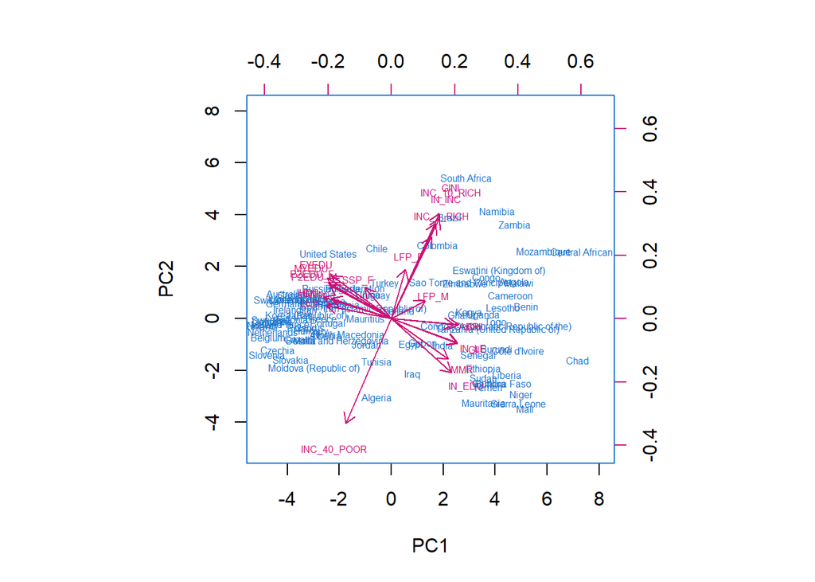

```r
biplot(pca, scale = 0, cex = 0.5, col = c("dodgerblue3", "deeppink3"))
```

Además, la longitud de los vectores representa la variabilidad de cada variable contenida en el CP.

- los scores están representados por las observaciones, es decir, por los nombres de cada país, y están agrupadas en función de la similitud de los valores de PC1 y PC2.

#### 4. ¿Con cuantas componentes te quedarías para representar de forma resumida toda la información contenida en los datos?

```
[1] "proportions of variance:"
 [1] 6.396663e-01 1.319683e-01 7.148217e-02 4.249575e-02 3.225616e-02
 [6] 1.757030e-02 1.493156e-02 1.178781e-02 9.049448e-03 6.848764e-03
[11] 6.034215e-03 5.659449e-03 3.178691e-03 2.944387e-03 1.396018e-03
[16] 1.179909e-03 8.691869e-04 5.410141e-04 1.324237e-04 7.941162e-06
[21] 1.949811e-07
```

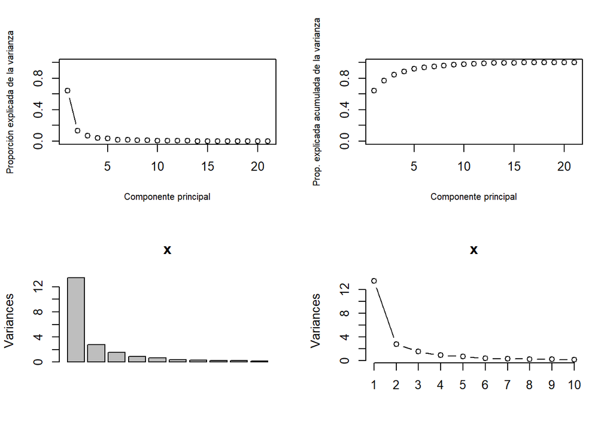

```r
pcaCharts <- function(x) {
    x.var <- x$sdev ^ 2
    x.pvar <- x.var/sum(x.var)
    print("proportions of variance:")
    print(x.pvar)

    par(mfrow=c(2,2))
    plot(x.pvar,xlab="Componente principal", ylab="Proporción explicada de la varianza", ylim=c(0,1), type='b', cex.lab=0.75)
    plot(cumsum(x.pvar),xlab="Componente principal", ylab="Prop. explicada acumulada de la varianza", ylim=c(0,1), type='b', cex.lab=0.75)
    screeplot(x)
    screeplot(x,type="l")
    par(mfrow=c(1,1))
}

pcaCharts(pca)
```

El gráfico arriba a la izquierda muestra la proporción explicada de la varianza de cada componente principal, mientras que el de arriba a la derecha muestra la varianza explicada acumulada. En este primer gráfico, y teniendo en cuenta la regla del codo, se seleccionarían los primeros dos CPs.

Luego, los dos gráficos de abajo son screeplots, y muestran cuánta variación captura cada uno de los CPs, siendo el eje `y` los valores propios de los CPs.

Como se mencionó en el primer apartado, el primer Componente Principal explica el 64% de la variación total de los datos, mientras que la segunda el 13,2%. Estos dos CP explican el 77,16% de la variación de los datos, mientras que entre las primeras tres CPs se explica casi el 85%.

Por lo tanto, aunque la regla del codo indique que el número de CP debería ser 2, me quedaría con 3 CPs, para poder explicar más del 80% de la variación total de los datos.

#### 5. Calcula las componentes principales de las variables LEB, EYEDU, MYEDU y GNIpc. Estudia sus vectores de carga y comenta dichos resultados en función de cómo pondera el IDH los diferentes indicadores. ¿Con cuantas componentes principales te quedarías?

```r
ocde_vars <- select(df, LEB, EYEDU, MYEDU, GNIpc)
pca_ocde <- prcomp(ocde_vars, scale=TRUE)
summary(pca_ocde)
```

```
Importance of components:
                          PC1     PC2     PC3     PC4
Standard deviation     1.8793 0.42751 0.39013 0.36513
Proportion of Variance 0.8829 0.04569 0.03805 0.03333
Cumulative Proportion  0.8829 0.92862 0.96667 1.00000
```

```r
pca_ocde$rotation
```

```
             PC1         PC2        PC3        PC4
LEB   -0.5011125  0.34429599 -0.6275214  0.4863778
EYEDU -0.5015287  0.48465503  0.1186178 -0.7067590
MYEDU -0.5020071 -0.03525034  0.7344549  0.4553265
GNIpc -0.4953222 -0.80332259 -0.2296141 -0.2379204
```

```
[1] "proportions of variance:"
[1] 0.88292797 0.04569164 0.03805097 0.03332942
```

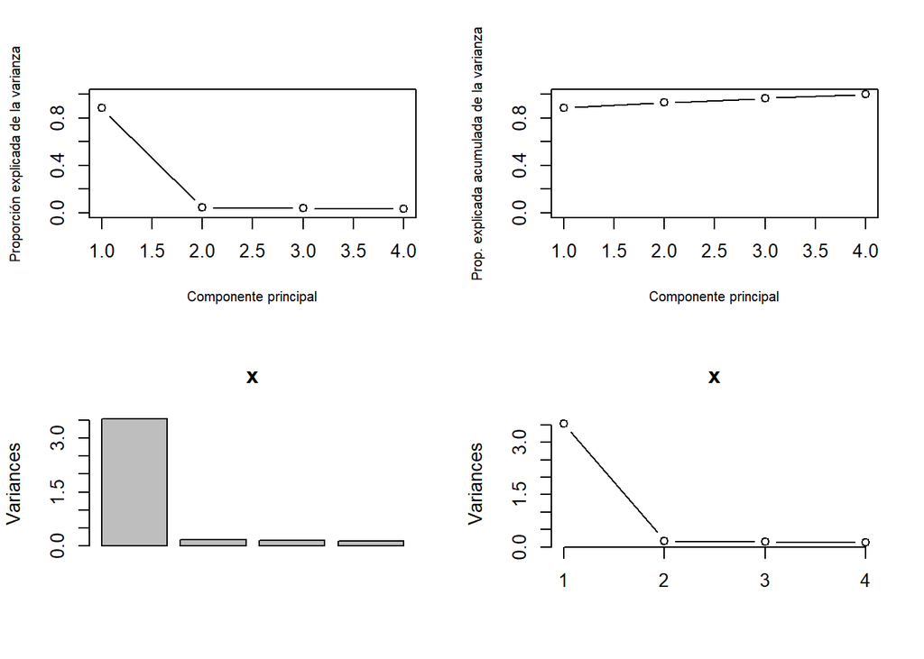

```r
pcaCharts(pca_ocde)
```

De los vectores de carga puede verse que el CP1 pondera de manera muy similar a las cuatro variables. El CP2 da mayor importancia, en terminos negativos, al producto bruto nacional per cápita (GNIpc). Los últimos dos CPs refieren a la educación: el CP3 pondera el nivel mínimo de educación, y el CP4 los años esperados de escolarización.

En vistas de la regla del codo, me quedaría con los dos primeros componentes, que explican el 92,86% de la variación total de los datos.